# Predictively Modeling Gentrification in Pittsburgh

**Dominic Bordelon**

Gentrification is a socioeconomic phenomenon seen in many postindustrial American cities. It is a driver of displacement of marginalized individuals and communities from their longtime homes.

In our local context, we investigate the following questions:

- Can we quantify and estimate gentrification locally using open (i.e., publicly available) data?
- How can we characterize a "pre-gentrification" or emergent gentrification area; in particular, which variables are strong predictors of gentrification?
- Can we predict where gentrification is likely to occur in Pittsburgh in the future?

Data sources: [Western Pennsylvania Regional Data Center](https://wprdc.org/); [US Census Bureau](https://www.census.gov/) (see full listing in Section 7).

Context: This analysis was proposed by WPRDC to undergraduate students of Dr. Amin Rahimian's [Data for Social Good course](https://catalog.upp.pitt.edu/preview_course_nopop.php?catoid=213&coid=1175552) at the University of Pittsburgh in Fall 2023. I was invited to mentor the students working on this problem. I guided the team's investigation generally: literature review, methodological approach, surveying and preprocessing of data, modeling, visualization, and interpretation. Their results can be seen on [the course GitHub repo](https://github.com/aminrahimian/data-for-good/blob/main/projects/2023/gentrification/GentrificationSocialGoodProject.ipynb). Since then, I have extended the investigation into the current analysis as a portfolio item.

## 1. Related work

We mimic the approach used by [William Thackway, et al. (2023)](https://doi.org/10.1016/j.cities.2023.104192) to predictively model gentrification in Sydney, Australia. Their 80 predictor variables include age, country of birth, education level, employment status, income, occuptation, rental/ownership, housing prices and supply, number of food and leisure businesses, and others. Their model is a random forest regressor which predicts ranking in an inequality index, SEIFA, developed by the Australian Bureau of Statistics.

## 2. Methods

We utilize the publicly available [Housing Market Value Analysis 2021](https://data.wprdc.org/dataset/market-value-analysis-2021), which is a unsupervised cluster analysis, labeling block groups in Allegheny County with an "MVA category" A through J. We select one of these categories, F, as an estimator of "emergent gentrification." While this data set is convenient, we should note that it is focused only on housing market values and types of housing markets within the region--the MVA is not itself concerned with gentrification nor would it capture social dimensions of gentrification.

The market value categories are as follows:

- "A" markets have the highest housing values, experience the largest level of new construction, have the highest owner occupancy levels, and experience little housing distress (such as residential vacancy and foreclosure).
- "B" markets have elevated housing values, experience substantial amounts of new construction, have more renters than owners, and experience little housing distress.
- "C" markets have above average housing values, experience about average levels of new constructon, have the highest levels of owner occupancy, and experience little housing distress.
- "D" markets have average housing values, experience half the countywide average amount of new construction, have more renters than owners, experience average levels of foreclosure, and have low levels of vacant lots and poor or worse condition properties.
- "E" markets have slightly lower than average housing values, experience little new construcion, have high levels of owner occupancy, have above average amounts of vacant land, and about aveage levels of foreclosure.
- **"F" markets have slightly lower than average housing values, experience slightly above average amounts of new construction, have more owners than renters, and have high levels of renters with a subsidy.**
- "G" markets have below average housing values, experience little new construction, have more owners than renters, and experience above average levels of foreclosure and residential vacant land.
- "H" markets have housing values well below the countywide average, exprience little new construction, have about even numbers of renters and owners, have the highest share of residential vacant land, and the highest levels of foreclosure.
- "I" markets have the second lowest housing values, experience very little new construction, have the highest share of renters with a subsidy, experience the highest levels of building violations, and have elevated shares of poor or worse condition properties, vacant residential lot area, and foreclosure.
- "J" markets have the lowest housing values (although there is a substantial amount of variability in those prices), more renters than homeowners, the highest share of poor or worse condition properties, and elevated shares of building violations, vacant lots, and foreclosure.

A-C are described as "Robust;" D-F are "Steady;" G and H are "Transitional," and I and J are "Stressed." We focus on F as the site of emergent or incipient gentrification because of lower than average housing values (prone to targeting), above average new construction (e.g., luxury condominiums), and high levels of renters with subsidy (more vulnerable to displacement than other classes of residents).

Most of the available Census and housing data is aggregated to the tract level. The MVA, however, labels market categories at the block group level (multiple block groups comprise a tract). We therefore normalize the MVA categories proportionally within each tract, using population. Each tract has ten new variables for the MVA categories, collectively summing to 1.0.

Another way we practice convenience sampling is that many of the WPRDC datasets begin in 2012 with yearly observations thereafter. Given that the 2021 MVA analysis was based on 2017-19 data, we thought it would be interesting to treat these MVA labels as "outcomes" of 2012 data. Therefore we fit a regressor which treats 2012 data as $X$ and ~2017 MVA conditions as $Y$. We utilize a regressor rather than a classifier since the MVA categories have been converted to proportional (i.e., numeric) dummy variables. We choose random forest as our modeling method because Thackway et al. (2023) use this method; because it is said to typically deliver good results; and because it can handle a multi-output $Y$ (one value for each proportional MVA dummy variable).

Once a model is fit, we will generate predictions using 2020 housing and Census data, representing MVA category composition at some future time. This will produce predicted MVA 10-category makeup for all tracts. Since we are interested only in category F, we will then caculate the predicted change in F proportion for each tract. Those tracts with a high F prediction or a high rate of growth prediction in F are at risk of gentrification. Given the large number of predictors, we will use a feature selection heuristic to somewhat simplify the model. We will assess the model's accuracy on both training and test (holdout) data, and then tune the model to reduce overfitting.

## 3. Data Preparation

The data are available in a variety of files and formats. We need them in a single, clean table to use the random forest regressor.

*Skip ahead to Section 4 if you are interested only in the model, and not in the extract-transform-load process.*

```python
import numpy as np
import pandas as pd
import geopandas as gpd

import matplotlib.pyplot as plt
import seaborn as sns
```

### 3.1 Market Value Analysis 2021 data

```python
mva = pd.read_csv("data/Pitts_Allegheny_MVA2021.csv")
geoid_mva = mva.iloc[:, [0, 10]]
pd.set_option('display.float_format', lambda x: '%.3f' % x)
print((geoid_mva.geoid.min(), geoid_mva.geoid.max()))
```

```
('420030103001', '420039822001')
```

The MVA geoid's are all 12 digits which is the [Census Block Group level](https://www.census.gov/programs-surveys/geography/guidance/geo-identifiers.html). The **tract** is the first 11 digits.

```python
geoid_mva["tract"] = geoid_mva["geoid"].apply(lambda x: x[0:11])
geoid_mva.head()
```

|  | geoid | MVA21 | tract |
| --- | --- | --- | --- |
| 0 | 420031014003 | B | 42003101400 |
| 1 | 420031014004 | C | 42003101400 |
| 2 | 420031016001 | F | 42003101600 |
| 3 | 420031017001 | G | 42003101700 |
| 4 | 420031017002 | G | 42003101700 |

Remove non-categorized geoids:

```python
geoid_mva = geoid_mva.loc[geoid_mva.MVA21 != "NC"]
```

#### 3.1.1 Join 2010 block-group level population to MVA

We will weight the tract-level classes according to population, so we need to join the population for each tract to the DataFrame. We approximate the 2012 block-level population by using the 2010 decennial census; block-level population is not available for 2012.

```python
pop_2010 = pd.read_csv("data/census_raw/DECENNIALSF12010.P1-Data.csv")
pop_2010 = pop_2010.iloc[2:, [0, 2]]
pop_2010["P001001"] = pd.to_numeric(pop_2010["P001001"], errors="coerce")
pop_2010["geoid"] = pop_2010["GEO_ID"].str.replace('.*US', '', regex=True)
pop_2010 = pop_2010.iloc[:, [2, 1]].rename(columns={"P001001": "geoid_pop"})
pop_2010.head()
```

|  | geoid | geoid_pop |
| --- | --- | --- |
| 2 | 420030103001 | 2594 |
| 3 | 420030103002 | 3336 |
| 4 | 420030103003 | 353 |
| 5 | 420030103004 | 317 |
| 6 | 420030201001 | 1435 |

```python
geoid_mva = geoid_mva.merge(pop_2010, on="geoid", how="left")
geoid_mva.head()
```

|  | geoid | MVA21 | tract | geoid_pop |
| --- | --- | --- | --- | --- |
| 0 | 420031014003 | B | 42003101400 | 822.000 |
| 1 | 420031014004 | C | 42003101400 | 730.000 |
| 2 | 420031016001 | F | 42003101600 | 857.000 |
| 3 | 420031017001 | G | 42003101700 | 607.000 |
| 4 | 420031017002 | G | 42003101700 | 858.000 |

#### 3.1.2. Transform MVA to tract-level dummy variables

Each dummy variable will be a proportion 0-1 of tract MVA composition, based on `geoid_pop` and `tract_pop`.

```python
tract_pop = geoid_mva.groupby(['tract'])['geoid_pop'].sum().reset_index(name="tract_pop")
geoid_mva = geoid_mva.merge(tract_pop, on="tract", how="left")

# columns A, B, C, ...
mva_wide = pd.pivot_table(geoid_mva, values="geoid_pop", index="geoid", columns="MVA21", aggfunc="first").reset_index()
geoid_mva = geoid_mva.merge(mva_wide, on="geoid", how="left")

# one row per tract, each MVA class summed:
tract_mva_sums = geoid_mva.groupby(['tract'])[['A', 'B', 'C', 'D', 'E', 'F', 'G', 'H', 'I', 'J']].sum().reset_index()
tract_mva_sums = geoid_mva.iloc[:, [2, 4]].drop_duplicates().merge(tract_mva_sums, on="tract", how="left")

# proportional classes:
mva_classes = ['A', 'B', 'C', 'D', 'E', 'F', 'G', 'H', 'I', 'J']
tract_mva_sums[mva_classes] = tract_mva_sums[mva_classes].div(tract_mva_sums['tract_pop'], axis=0)

tract_mva = tract_mva_sums.drop('tract_pop', axis=1)
tract_mva.head()
```

|  | tract | A | B | C | D | E | F | G | H | I | J |
| --- | --- | --- | --- | --- | --- | --- | --- | --- | --- | --- | --- |
| 0 | 42003101400 | 0.000 | 0.446 | 0.218 | 0.336 | 0.000 | 0.000 | 0.000 | 0.000 | 0.000 | 0.000 |
| 1 | 42003101600 | 0.000 | 0.000 | 0.000 | 0.000 | 0.000 | 1.000 | 0.000 | 0.000 | 0.000 | 0.000 |
| 2 | 42003101700 | 0.000 | 0.000 | 0.000 | 0.000 | 0.000 | 0.000 | 1.000 | 0.000 | 0.000 | 0.000 |
| 3 | 42003101800 | 0.000 | 0.000 | 0.399 | 0.000 | 0.601 | 0.000 | 0.000 | 0.000 | 0.000 | 0.000 |
| 4 | 42003110200 | 0.185 | 0.815 | 0.000 | 0.000 | 0.000 | 0.000 | 0.000 | 0.000 | 0.000 | 0.000 |

### 3.2 Read parcel centroids and join neighborhood names

```python
parcel_centroids = pd.read_csv("data/parcelcentroid2022_08wgs.csv")
```

```python
# parcel_centroids.columns

parcels = parcel_centroids.loc[:, ['GEOID10', 'Latitude', 'Longitude', 'geo_name_n', 'geo_name_1']]
parcels["tract"] = parcels["GEOID10"].apply(lambda x: str(x)[0:11] if len(str(x)) > 0 else "")
parcels = parcels.drop_duplicates(["tract"])
parcels = parcels.rename(columns={
    "geo_name_n": "neighborhood",
    "geo_name_1": "municipality"
})
parcels = parcels.iloc[:, [-1, 1, 2, 4, 3]]
parcels.head()
```

|  | tract | Latitude | Longitude | municipality | neighborhood |
| --- | --- | --- | --- | --- | --- |
| 0 | 42003418000 | 40.540 | -79.798 | Cheswick borough |  |
| 1 | 42003480101 | 40.344 | -79.988 | Baldwin borough |  |
| 2 | 42003486700 | 40.380 | -79.855 | Duquesne city |  |
| 3 | 42003496101 | 40.278 | -79.821 | Elizabeth township |  |
| 4 | 42003450700 | 40.511 | -80.158 | Coraopolis borough |  |

```python
tract_mva = tract_mva.merge(parcels, on="tract", how="left")
tract_mva.head()
```

[output not shown]

### 3.3 Census data

I have prepared the Census data in a separate notebook, 0_census_preprocessing.ipynb.

The predictors we will consider from the Census data are:

- Age
- Educational attainment
- Housing units
- Selected economic characteristics: unemployment rate, median household income
- Race and ethnicity
- Selected social characteristics: average household size
- Mortgages (median value, median real estate taxes)
- Selected housing characteristics: rental vacancy rate, renter-occupied percentage, moved in the last decade

```python
census2012 = pd.read_csv("data/census_clean/census_2012.csv")
census2012['tract'] = census2012['tract'].apply(str)

census2020 = pd.read_csv("data/census_clean/census_2020.csv")
census2020['tract'] = census2020['tract'].apply(str)
```

### 3.4 Joining MVA + census

```python
tract_mva_2012 = tract_mva.merge(census2012, on="tract", how="left")

tract_2020 = tract_mva.iloc[:, [0]].merge(census2020, on="tract", how="left")
```

### 3.5 Housing data

#### 3.5.1 Parcels-to-sales ratio

We will keep only the calculated ratio (num. parcels / num. sales). Since this table has many years, we will extract both 2012 and 2020 from it.

```python
parcels_to_sales = pd.read_csv("data/parcelstosales.csv")
parcels_to_sales = parcels_to_sales.rename(columns={"geo_id_tract": "tract",
                                                    "parcels-sales": "parcels_sales_ratio"})
parcels_to_sales["tract"] = pd.to_numeric(parcels_to_sales["tract"], errors="coerce").astype("str")
parcels_to_sales = parcels_to_sales.iloc[:, [0, 2, 4]] # tract, year, parcels_sales_ratio

parcels_to_sales2012 = parcels_to_sales.loc[parcels_to_sales.year == 2012].iloc[:,[0,2]]
parcels_to_sales2020 = parcels_to_sales.loc[parcels_to_sales.year == 2020].iloc[:,[0,2]]

parcels_to_sales2012.head()
```

|  | tract | parcels_sales_ratio |
| --- | --- | --- |
| 0 | 42003010300 | 23.400 |
| 1 | 42003020100 | NaN |
| 2 | 42003020300 | 53.000 |
| 3 | 42003030500 | 99.300 |
| 4 | 42003040200 | 32.500 |

#### 3.5.2 Vacant addresses ratio

```python
vac_addresses = pd.read_csv("data/PAVacantAddresses.csv")
vac_addresses = vac_addresses.rename(columns={"geoid": "tract"})
```

```python
va_2012 = vac_addresses[vac_addresses['quarter'].str.startswith('12')]
va_2012_agg = vac_addresses.groupby(['tract'])['total_avg_vac'].mean().reset_index(name="vac_days_avg")
va_2012_agg['tract'] = va_2012_agg['tract'].astype(str)

va_2020 = vac_addresses[vac_addresses['quarter'].str.startswith('20')]
va_2020_agg = vac_addresses.groupby(['tract'])['total_avg_vac'].mean().reset_index(name="vac_days_avg")
va_2020_agg['tract'] = va_2020_agg['tract'].astype(str)
```

### 3.6 Joining MVA + census + housing

```python
tract_mva_2012 = tract_mva_2012.merge(parcels_to_sales2012, on="tract", how="left"
                                     ).merge(va_2012_agg, on="tract", how="left")

tract_2020 = tract_2020.merge(parcels_to_sales2020, on="tract", how="left"
                                     ).merge(va_2020_agg, on="tract", how="left")
```

### 3.7 Drop `NaN`

**NOTE:** We will need to re-evaluate missingness prior to fitting our model, to ensure we aren't dropping too much. Some values may need to be imputed.

```python
tract_mva_2012 = tract_mva_2012.dropna()
tract_2020 = tract_2020.dropna()
```

## 4. Fitting and tuning a random forest regression model

Following Thackway et al. (2023), we now implement a random forest regressor in order to predict future areas of gentrification. More specifically, the output or $Y$ of this model will be an array of ten numeric values, corresponding to the ten dummy variables created in Section 3.1.2; each dummy variable is a proportion of MVA class membership, A through J.

Prior to estimating the predictions, we must fit ("train") the model. To accomplish this, we treat the 2021 MVA categories (based on 2017-19 data) as outputs of 2012 data. The time lag between 2012 and 2017 accounts roughly for the passage of time. So in summary, in fitting the model, $Y$ will be 2021 MVA categories, and $X$ will be the many predictors we have chosen.

Once an initial model is fit, we will evaluate its performance according to accuracy and explore possible improvements.

### 4.1 Fitting and feature selection

We have very many predictors, not all of which may be useful for our model. Therefore, we will use `sklearn.feature_selection.SelectFromModel()` to select only the more relevant half of all the features.

```python
from sklearn.model_selection import train_test_split, PredefinedSplit
from sklearn.ensemble import RandomForestRegressor
from sklearn.feature_selection import SelectFromModel
from sklearn.metrics import mean_squared_error
from sklearn.tree import plot_tree
```

```python
# population etc. to the end:
X_all = tract_mva_2012.iloc[:, 14:]

# mva proportions:
y_all = tract_mva_2012.iloc[:, 1:11]

X_train, X_test, y_train, y_test = train_test_split(X_all, y_all, test_size=0.2, random_state=85)
```

```python
rf_regressor = SelectFromModel(RandomForestRegressor(n_estimators=100, random_state=85), threshold="median")
rf_regressor.fit_transform(X_train, y_train)
```

```
array([[6.500e+00, 6.400e+00, 6.400e+00, ..., 1.592e+05, 3.731e+03,
        2.970e+01],
       [1.160e+01, 7.800e+00, 2.800e+00, ..., 5.220e+04, 4.920e+02,
        8.670e+01],
       [7.500e+00, 4.200e+00, 3.300e+00, ..., 7.890e+04, 1.687e+03,
        3.020e+01],
       ...,
       [3.600e+00, 4.700e+00, 8.700e+00, ..., 2.271e+05, 5.594e+03,
        1.790e+01],
       [7.900e+00, 9.800e+00, 5.600e+00, ..., 2.022e+05, 5.163e+03,
        1.520e+01],
       [1.800e+00, 1.000e-01, 3.300e+00, ..., 4.833e+05, 6.687e+03,
        1.920e+01]])
```

```
[Text(0.5, 1.0, 'RF feature importance')]
```

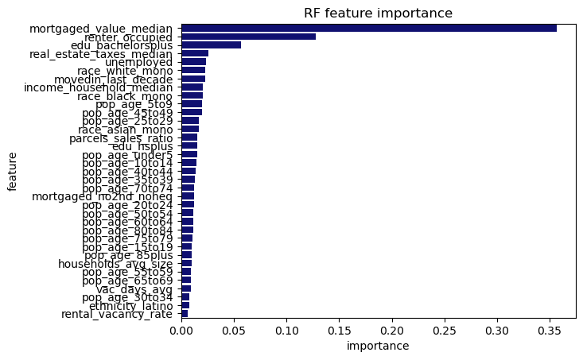

```python
feature_importance = pd.DataFrame({'feature': tract_mva_2012.iloc[:, 14:].columns,
                                   'importance': rf_regressor.estimator_.feature_importances_})
feature_importance = feature_importance.sort_values("importance", ascending=False)
sns.barplot(y='feature', x='importance', data=feature_importance, orient="h", color="navy").set(title = "RF feature importance")
```

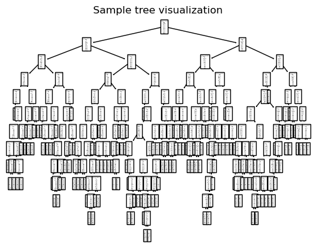

```python
plt.figure()
plot_tree(rf_regressor.estimator_.estimators_[0], label="none")
plt.title("Sample tree visualization")
plt.show()
```

Visualizing a sample tree shows that we have a complex specification (defying easy visualization), but that there is a depth of 12.

### 4.2 Model evaluation

With some understanding of our model's findings, we would like to next evaluate how accurate they appear to be.

Before fitting the model, we split the data in to `train` and `test` sets at an 80:20 ratio. Now we will run the previously unseen `test` data through the model and compare the predictions to the known values.

```python
y_pred = rf_regressor.estimator_.predict(X_test)
mse_test = mean_squared_error(y_test, y_pred)
print("Mean Squared Error for test set:", mse_test)
```

```
Mean Squared Error for test set: 0.03827092842476781
```

Our model has a mean squared error (MSE) of 3.8% on the test set. This seems quite good, but perhaps we should be concerned about overfitting. How does this compare to the MSE of the model on the training data?

```python
y_pred = rf_regressor.estimator_.predict(X_train)
mse_train = mean_squared_error(y_train, y_pred)
print("Mean Squared Error for training set:", mse_train)
```

```
Mean Squared Error for training set: 0.00431211639235711
```

Another way to evaluate the model is according to its $R^2$ score. It answers the question, "how much of the model's output is explained by the inputs?" There are necessarily practical limits on $R^2$ (i.e., irreducible error) because of unaccounted-for factors, but we would like the model to have similar $R^2$ on both training and test sets.

```python
print(f"training R^2: {rf_regressor.estimator_.score(X_train, y_train)}\ntest R^2: {rf_regressor.estimator_.score(X_test, y_test)}")
```

```
training R^2: 0.9120990088771134
test R^2: 0.32706935728830866
```

This large difference (91% on training vs. 33% on test) indicates overfitting. Let us attempt to tune the model for better performance on test data.

### 4.3 Model tuning

Although the `RandomizedSearchCV` includes a k-fold cross-validation splitter, I found through trial and error that $R^2$ was very low on test data, maxing at around 25%. Therefore, we will try retaining the test data until the end and testing only on the best model.

```python
from sklearn.pipeline import Pipeline
from sklearn.model_selection import RandomizedSearchCV
from scipy.stats import randint
```

```python
pipe = Pipeline([
    ('feature_selection', SelectFromModel(RandomForestRegressor(n_estimators=100))),
    ('regressor', RandomForestRegressor(n_estimators=100))
])

param_dist = {
    'feature_selection__threshold': ['mean', 'median', '1.25*mean'],
    'regressor__max_depth': [None, 2, 4, 6, 10],
    'regressor__min_samples_split': randint(2, 11),
    'regressor__min_samples_leaf': randint(1, 5)
}

random_search = RandomizedSearchCV(pipe,
                                   param_distributions=param_dist,
                                   n_iter=2,
                                   cv=5,  # bypass k-fold
                                   scoring='r2',
                                   verbose=0,
                                   random_state=85,
                                   return_train_score=True)
random_search.fit(X_train, y_train)
best_model = random_search.best_estimator_

print(f"R^2 of training set: {best_model.score(X_train, y_train)}\n")
```

```
R^2 of training set: 0.6934192699845242
```

```python
y_pred_test = best_model.predict(X_test)

test_r2_score = best_model.score(X_test, y_test)
print(f"R^2 of test data: {test_r2_score}")
```

```
R^2 of test data: 0.32222869723303826
```

Despite our best efforts, it looks like 32% is the best $R^2$ we can achieve using these data and this method. This is perhaps not very surprising considering the complexity of the system we are studying, and the time lag component.

```python
feat_imp = best_model.named_steps["regressor"].feature_importances_
# feature_importance = pd.DataFrame({'feature': tract_mva_2012.iloc[:, 14:].columns,
#                                    'importance': best_model.estimator_.feature_importances_})
# feature_importance = feature_importance.sort_values("importance", ascending=False)
# sns.barplot(y='feature', x='importance', data=feature_importance, orient="h", color="navy").set(title = "RF feature importance")
```

[output not shown]

```python
# population etc. to the end:
X_all = tract_mva_2012.iloc[:, 14:]

y_all = tract_mva_2012.F
X_train, X_test, y_train, y_test = train_test_split(X_all, y_all, test_size=0.2, random_state=85)
```

```python
pipe = Pipeline([
    ('feature_selection', SelectFromModel(RandomForestRegressor(n_estimators=100))),
    ('regressor', RandomForestRegressor(n_estimators=100))
])

param_dist = {
    'feature_selection__threshold': ['mean', 'median', '1.25*mean'],
    'regressor__max_depth': [None, 2, 4, 6, 10],
    'regressor__min_samples_split': randint(2, 11),
    'regressor__min_samples_leaf': randint(1, 5)
}

random_search = RandomizedSearchCV(pipe,
                                   param_distributions=param_dist,
                                   n_iter=100,
                                   cv=5,  # bypass k-fold
                                   scoring='r2',
                                   verbose=0,
                                   random_state=85,
                                   return_train_score=True)
random_search.fit(X_train, y_train)
best_model = random_search.best_estimator_

print(f"R^2 of training set: {best_model.score(X_train, y_train)}\n")
```

```
R^2 of training set: 0.45807743029668757
```

```python
rf_regressor = SelectFromModel(RandomForestRegressor(n_estimators=100, random_state=85), threshold="median")
rf_regressor.fit_transform(X_train, y_train)
rf_regressor.estimator_.score(X_train, y_train)
```

```
0.8371528177226472
```

83.7% is a strong result, however, upon further inspection, the $R^2$ of both of these models is negative for the test set (not shown)! These are bad models, so we will keep the multi-output model.

```python
# population etc. to the end:
X_all = tract_mva_2012.iloc[:, 14:]

# mva proportions:
y_all = tract_mva_2012.iloc[:, 1:11]

X_train, X_test, y_train, y_test = train_test_split(X_all, y_all, test_size=0.2, random_state=85)
```

```python
rf_regressor = SelectFromModel(RandomForestRegressor(n_estimators=100, random_state=85), threshold="median")
rf_regressor.fit_transform(X_train, y_train)
```

```
array([[6.500e+00, 6.400e+00, 6.400e+00, ..., 1.592e+05, 3.731e+03,
        2.970e+01],
       [1.160e+01, 7.800e+00, 2.800e+00, ..., 5.220e+04, 4.920e+02,
        8.670e+01],
       [7.500e+00, 4.200e+00, 3.300e+00, ..., 7.890e+04, 1.687e+03,
        3.020e+01],
       ...,
       [3.600e+00, 4.700e+00, 8.700e+00, ..., 2.271e+05, 5.594e+03,
        1.790e+01],
       [7.900e+00, 9.800e+00, 5.600e+00, ..., 2.022e+05, 5.163e+03,
        1.520e+01],
       [1.800e+00, 1.000e-01, 3.300e+00, ..., 4.833e+05, 6.687e+03,
        1.920e+01]])
```

## 5. Predicting future MVA proportions using 2020 input data

We should be careful not to draw strong conclusions from such a weak model. But here we will work through the exercise of predicting 2020 sites of gentrification, to show how the reasoning would work.

```python
pred_2020 = rf_regressor.estimator_.predict(tract_2020.iloc[:, 1:])

pred_2020
```

```
array([[0.00297589, 0.04181782, 0.37950486, ..., 0.        , 0.        ,
        0.        ],
       [0.00518941, 0.01555094, 0.33997572, ..., 0.        , 0.        ,
        0.        ],
       [0.07490145, 0.44388788, 0.15821967, ..., 0.        , 0.        ,
        0.        ],
       ...,
       [0.        , 0.34418509, 0.01      , ..., 0.06620257, 0.04924358,
        0.01995251],
       [0.        , 0.03626737, 0.21352148, ..., 0.00480312, 0.        ,
        0.        ],
       [0.00677215, 0.35541767, 0.00276009, ..., 0.14307386, 0.01915361,
        0.03178365]])
```

```python
y_2020 = pd.DataFrame(pred_2020, columns=mva_classes)
```

These predictions are not very interesting on their own. We will join the 2012 and predicted 2020 values together to calculate a predicted delta, and then sort the tracts by those with a highest delta in the F class.

```python
y_2020['tract'] = tract_2020['tract']
mva_props_2012 = tract_mva_2012.iloc[:, :11].rename(columns={'A': 'A_2012',
                                            'B': 'B_2012',
                                            'C': 'C_2012',
                                            'D': 'D_2012',
                                            'E': 'E_2012',
                                            'F': 'F_2012',
                                            'G': 'G_2012',
                                            'H': 'H_2012',
                                            'I': 'I_2012',
                                            'J': 'J_2012'})

mva_delta = y_2020.merge(mva_props_2012, on="tract")
mva_delta['F_delta'] = mva_delta.F - mva_delta.F_2012

mva_delta = mva_delta.sort_values('F_delta', ascending=False).reset_index().drop('index', axis=1)

# we only care about F_delta for now:
mva_delta = mva_delta.loc[:, ['tract', 'F_delta']]
mva_delta.iloc[0:9, :]
```

|  | tract | F_delta |
| --- | --- | --- |
| 0 | 42003552400 | 0.151 |
| 1 | 42003551900 | 0.107 |
| 2 | 42003508000 | 0.099 |
| 3 | 42003476100 | 0.097 |
| 4 | 42003191700 | 0.089 |
| 5 | 42003523400 | 0.089 |
| 6 | 42003507000 | 0.081 |
| 7 | 42003451102 | 0.079 |
| 8 | 42003477100 | 0.076 |

```python
mva_delta_geo = mva_delta.merge(parcels, on="tract")
mva_delta_geo.iloc[0:9, :]
```

|  | tract | F_delta | Latitude | Longitude | municipality | neighborhood |
| --- | --- | --- | --- | --- | --- | --- |
| 0 | 42003552400 | 0.151 | 40.331 | -79.844 | McKeesport city |  |
| 1 | 42003551900 | 0.107 | 40.352 | -79.853 | McKeesport city |  |
| 2 | 42003508000 | 0.099 | 40.389 | -79.811 | Wilmerding borough |  |
| 3 | 42003476100 | 0.097 | 40.357 | -80.029 | Castle Shannon borough |  |
| 4 | 42003191700 | 0.089 | 40.408 | -80.013 | Pittsburgh city | Brookline |
| 5 | 42003523400 | 0.089 | 40.457 | -79.829 | Penn Hills township |  |
| 6 | 42003507000 | 0.081 | 40.381 | -79.810 | East McKeesport borough |  |
| 7 | 42003451102 | 0.079 | 40.518 | -80.214 | Moon township |  |
| 8 | 42003477100 | 0.076 | 40.359 | -80.005 | Whitehall borough |  |

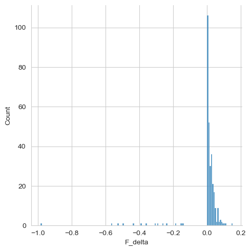

```python
sns.displot(data=mva_delta_geo, x="F_delta")
```

`F_delta` shows an interesting distribution. It may be useful to apply a logarithmic transformation, especially for visualization purposes. This will require us to drop negative and zero values.

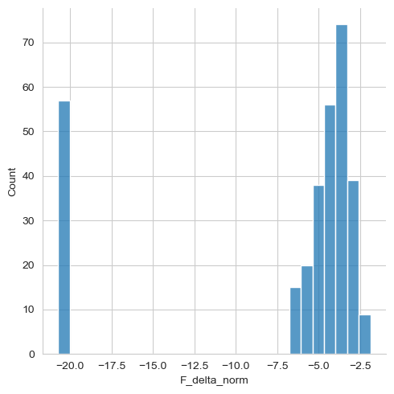

```python
mva_delta_geo['F_delta_norm'] = mva_delta_geo.F_delta.clip(lower=0)
mva_delta_geo['F_delta_norm'] += 1e-9
mva_delta_geo['F_delta_norm'] = np.log(mva_delta_geo['F_delta_norm'])

sns.displot(data=mva_delta_geo, x="F_delta_norm")
```

This is something we will be able to plot on a map. To simplify the visualization (and avoid skewing the color scale), let us filter out the spike around -20, which were negative and zero values anyway. This will not be "dishonest" in our map since we are highlighting only the findings of interest.

```python
boundary_df = gpd.read_file('data/allegheny_county_boundary.shp')
```

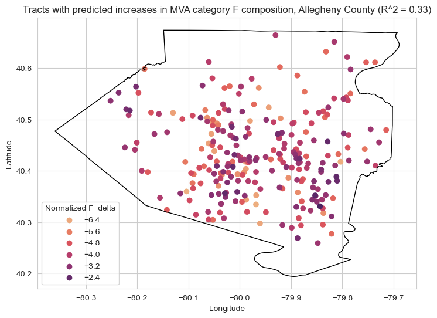

```python
delta_highlights = mva_delta_geo[mva_delta_geo.F_delta_norm > -18].sort_values('F_delta_norm')

sns.set_style("whitegrid")

plt.figure(figsize=(10, 6))
scatter = sns.scatterplot(data=delta_highlights,
                          x='Longitude',
                          y='Latitude',
                          hue='F_delta_norm',
                          palette='flare',
                          s=50,
                          edgecolor='none', legend='brief')
boundary_df.boundary.plot(ax=plt.gca(), linewidth=1, color='k')  # 'gca' gets the current Axes instance, 'k' sets the color black

plt.title('Tracts with predicted increases in MVA category F composition, Allegheny County (R^2 = 0.33)')
plt.xlabel('Longitude')
plt.ylabel('Latitude')

# Display the color legend
plt.legend(title='Normalized F_delta', loc='best')

# Show the plot
plt.show()
```

More sophisticated maps are of course possible, e.g., with a shapefile for the tract boundaries, but the current map is functional for an exploratory analysis of an unreliable model.

## 6. Discussion

Returning to our initial questions, we have preliminary quantification of gentrification using an housing market value category, informed by many variables. In the feature importance visualization, we see that, after median mortgage value, strong predictors of F are renter occupation, education of bachelor's or higher, median real estate taxes, and unemployed status.

- A wider array of data, such as presence of business types, and more demographic Census variables (e.g., occupation/industry)
- Reducing the time gap between $X$ and $Y$ when fitting the model; ideally determining empirically an appropriate value.
- Utilizing time series analysis and data from multiple years.
- Taking into account distances (e.g., from downtown) and/or other forms of GIS modeling.
- Experimenting with dimensionality reduction (e.g., PCA) or deep learning methods.

## 7. Data Sources and References

- Western Pennsylvania Regional Data Center:
  - [2010 Census Blocks with Geographic Codes Southwestern PA](https://data.wprdc.org/dataset/2010-census-blocks-with-geographic-codes-southwestern-pa) (neighborhood names, tract centroids)
  - [Housing Market Value Analysis 2021](https://data.wprdc.org/dataset/market-value-analysis-2021): cluster analysis of 2017-19 data, used to characterize the Pittsburgh housing market into 10 groups
  - [Housing Indicators](https://data.wprdc.org/dataset/housing-indicators), 2012 and 2020
    - Profiles Format - foreclosure 2009-2021
    - Parcels-to-sales ratio, 2012-2021
    - Condo Sales Price 2021$ Tract, 2012-2021
    - Condo Sales Tract, 2012-2021
    - Average Sale Price Tract in 2021 $ 1 to 2 unit, 2012-2021
  - [PA Vacant Addresses](https://data.wprdc.org/dataset/vacant-addresses), 2012 and 2020
  - [Allegheny County Boundary](https://data.wprdc.org/dataset/allegheny-county-boundary)
- US Census:
  - Decennial Census, 2010: [P1 Total Population](https://data.census.gov/table/DECENNIALSF12010.P1)
  - American Community Survey 5-year estimates, 2012: [S0101 Age and Sex](https://data.census.gov/table/ACSST5Y2012.S0101), [S1501 Educational Attainment](https://data.census.gov/table/ACSST5Y2012.S1501), [B25001 Housing Units](https://data.census.gov/table/ACSDT5Y2012.B25001), [DP03 Selected Economic Characteristics](https://data.census.gov/table/ACSDP5Y2012.DP03), [DP05 ACS Demographic and Housing Estimates](https://data.census.gov/table/ACSDP5Y2012.DP05), [DP02 Selected Social Characteristics in the United States](https://data.census.gov/table/ACSDP5Y2012.DP02), [S2506 Financial Characteristics for Housing Units with a Mortgage](https://data.census.gov/table/ACSST5Y2012.S2506), [DP04 Selected Housing Characteristics](https://data.census.gov/table/ACSDP5Y2012.DP04)
  - American Community Survey 5-year estimates, 2020: [S0101 Age and Sex](https://data.census.gov/table/ACSST5Y2020.S0101), [S1501 Educational Attainment](https://data.census.gov/table/ACSST5Y2020.S1501), [B25001 Housing Units](https://data.census.gov/table/ACSDT5Y2020.B25001), [DP03 Selected Economic Characteristics](https://data.census.gov/table/ACSDP5Y2020.DP03), [DP05 ACS Demographic and Housing Estimates](https://data.census.gov/table/ACSDP5Y2020.DP05), [DP02 Selected Social Characteristics in the United States](https://data.census.gov/table/ACSDP5Y2020.DP02), [S2506 Financial Characteristics for Housing Units with a Mortgage](https://data.census.gov/table/ACSST5Y2020.S2506), [DP04 Selected Housing Characteristics](https://data.census.gov/table/ACSDP5Y2020.DP04)

### References

James, G., Witten, D., Hastie, T., & Tibshirani, R. (2021). *An introduction to statistical learning: With applications in R.* 2nd ed. Springer. https://doi.org/10.1007/978-1-0716-1418-1

Reades, J., De Souza, J., & Hubbard, P. (2019). Understanding urban gentrification through machine learning. *Urban Studies*, 56(5), 922–942. https://doi.org/10.1177/0042098018789054

Thackway, W., Ng, M., Lee, C.-L., & Pettit, C. (2023). Building a predictive machine learning model of gentrification in Sydney. *Cities*, 134, 104192. https://doi.org/10.1016/j.cities.2023.104192